# E03 - Estadística Inferencial

Equipo 1

2024-10-07

# Enunciado

En una planta química hay dos máquinas que envasan detergentes industriales en bidones con un volumen de producto que sigue una distribución normal con desviación estándar de 1 litro. La ingeniera a cargo de la planta debe asegurar que los bidones se están llenando con una media de 10 litros. Pero ella tiene la sospecha de que hay desviaciones en esta media, lo que piensa confirmar usando una muestra aleatoria de 100 envases (50 de cada una de las máquinas). También cree que hay diferencia en el cumplimiento del volumen requerido entre la máquina más antigua y la más moderna, que han de andar por el 90% y 96% de los bidones, respectivamente.

A partir del enunciado podemos recolectar los siguientes datos:

Desviación Estándar = 1 litro Media = 10 litros n = 100

Error Tipo II Maquina Antigua = 0,1 Maquina Nueva = 0,04

Por lo tanto, las hipótesis a formular en este caso son: H0: La media del llenado de los bidones es igual a 10 litros. HA: La media de llenado de los bidones es distinta de 10 litros.

En lenguaje matemático: Denotando μ como la media de llenado de los bidones:

```
H0: μ = μ0, esto es, μ = 10 litros.
HA: μ =/ μ0, es decir, μ =/ 10 litros.
```

## Pregunta 1

Si la ingeniera piensa rechazar la hipótesis nula cuando la muestra presente una media menor a 9,78 litros o mayor a 10,22 litros, ¿cuál es la probabilidad de que cometa un error de tipo I? Para responder, generen un gráfico de la distribución muestral de las medias hipotetizada en donde se marquen las zonas correspondientes a la probabilidad solicitada, para luego, basándose en este gráfico, calcular el área correspondiente. Tome como ejemplo los scripts presentados en la lectura sobre poder estadístico.

Como nos dicen que la media puede ser rechazada si esta es “menor a” o “mayor a” podemos decir que estamos ante una prueba bilateral.

Partimos anotando los datos conocidos:

```r
# Parámetros de la población y la muestra
media_poblacional <- 10
desviacion_estandar <- 1
#tamano muestra
n <- 100
#error estandar
SE <- desviacion_estandar / sqrt(n)

# Límites de rechazo para la hipótesis nula
x1 <- 9.78
x2 <- 10.22
```

Ahora graficamos las regiones de error de tipo I

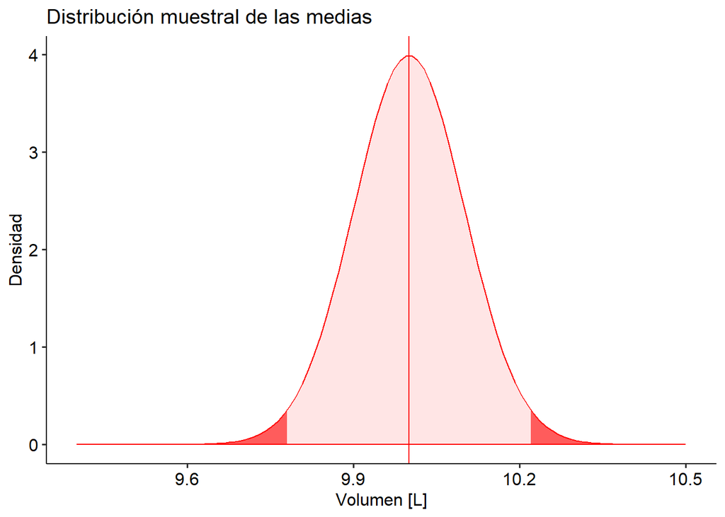

```r
# Crear una secuencia de valores para el eje x
x <- seq(media_poblacional - 4*SE, media_poblacional + 4*SE, length.out = 1000)

# Crear el gráfico base usando ggplot
g_x_limites <- media_poblacional + c(-6, 5) * SE
g <- ggplot() + xlim(g_x_limites)
g <- g + labs(x = "Volumen [L]", y = "Densidad")
g <- g + labs(title = "Distribución muestral de las medias")
g <- g + theme_pubr()

dist_0 <- stat_function(fun = dnorm,
                        args = list(mean = media_poblacional, sd = SE),
                        geom = "area",
                        colour = "red", fill = "red", alpha = 0.1)
g1 <- g + dist_0
g1 <- g1 + geom_vline(xintercept = media_poblacional, colour = "red")


g2 <- g1 + stat_function(fun = dnorm,
                         args = list(mean = media_poblacional, sd = SE),
                         geom = "area",
                         xlim = c(g_x_limites[1], x1),
                         fill = "red", alpha = 0.6)

g2 <- g2 + stat_function(fun = dnorm,
                         args = list(mean = media_poblacional, sd = SE),
                         geom = "area",
                         xlim = c(x2, g_x_limites[2]),
                         fill = "red", alpha = 0.6)
print(g2)
```

Podemos apreciar del gráfico que las regiones de rechazo son pequeñas por lo que se espera conseguir un nivel de significancia bajo.

Finalmente calculamos la probabilidad de cometer un error tipo I calculando las áreas de las regiones de rechazo:

```r
# Convertir los límites x1 y x2 en valores Z
Z1 <- (x1 - media_poblacional) / SE
Z2 <- (x2 - media_poblacional) / SE

# Calcular la probabilidad de cometer un error Tipo I
p_error_tipo_I <- (pnorm(Z1) + (1 - pnorm(Z2))) * 100

# Imprimir la probabilidad de cometer un error Tipo I
print(paste("Probabilidad de error Tipo I es alfa =", p_error_tipo_I))
```

```
## [1] "Probabilidad de error Tipo I es alfa = 2.78068950269967"
```

A partir de los límites de rechazo de la hipótesis nula planteados en el enunciado tenemos que la probabilidad de cometer un error de tipo I es de α= 0.028 aproximadamente.

# Problema 2: Si el verdadero volumen medio de los bidones fuera de 10,2 litros, ¿cuál sería la probabilidad de que la ingeniera, que obviamente no conoce este dato, cometa un error de tipo II? Para responder, agregue al gráfico anterior la verdadera distribución muestral de las medias y marquen (con otro color) la zona correspondiente a la probabilidad solicitada, para luego, basándose en este gráfico, calcular el área correspondiente. También hay ejemplos de este procedimiento en la lectura sobre poder estadístico.

Agregamos al gráfico que sacamos previamente la verdadera distribución muestral en color azul

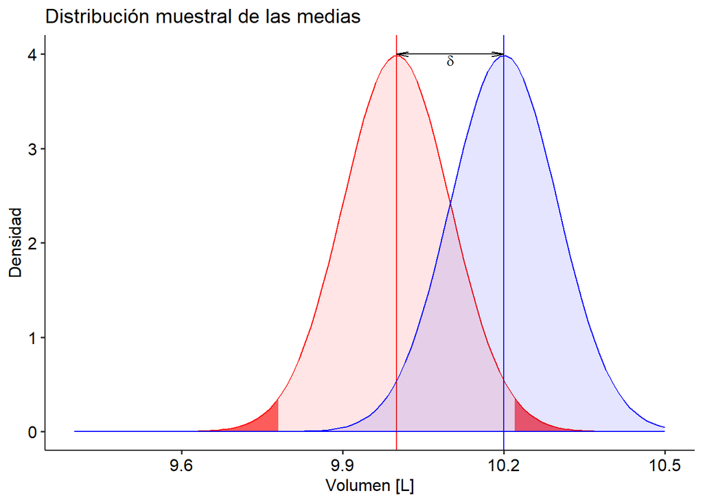

```r
# declaramos los datos proporcionados por el enunciado
media_verdadera = 10.2

# graficamos las áreas para el error tipo I (Alpha) y tipo II (Beta)
alpha_area <- pnorm(Z1) + (1 - pnorm(Z2))
beta_area <- pnorm(Z2, mean = media_verdadera, sd = SE) - pnorm(Z1, mean = media_verdadera, sd = SE)


# Zonas de rechazo para la media hipotética
Z1 <- (x1 - media_poblacional) / SE
Z2 <- (x2 - media_poblacional) / SE

# Áreas para el error tipo I (Alpha) y tipo II (Beta)
alpha_area <- pnorm(Z1) + (1 - pnorm(Z2))
beta_area <- pnorm(Z2, mean = media_verdadera, sd = SE) - pnorm(Z1, mean = media_verdadera, sd = SE)

# Agregar la verdadera distribución muestral de las medias.
dist_v <- stat_function(fun = dnorm,
                        args = list(mean = media_verdadera, sd = SE),
                        geom = "area",
                        colour = "blue", fill = "blue", alpha = 0.1)
g3 <- g2 + dist_v + geom_vline(xintercept = media_verdadera, colour = "blue")

# Agrega anotación del tamaño del efecto
x_ann <- c(media_verdadera, media_poblacional)
y_ann <- c(dnorm(media_verdadera, mean = media_verdadera, sd = SE),
           dnorm(media_poblacional, mean = media_poblacional, sd = SE))
y_ann <- y_ann + 0.01
g3 <- g3 + annotate("segment", x = x_ann[1], y = y_ann[1],
                    xend = x_ann[2], yend = y_ann[2],
                    arrow = arrow(angle = 10, length = unit(0.03, "npc"),
                                  ends = "both", type = "open"))
g3 <- g3 + annotate("text", x = sum(x_ann) / 2, y = y_ann[1] - 0.001,
                    label = "delta", vjust = "top", parse = TRUE)

print(g3)
```

Marcamos las áreas que corresponden al error de tipo II, las cuáles corresponden a las áreas fuera de las secciones críticas establecidas (9.78 [L] ; 10.22[L]) zona apuntada por β.

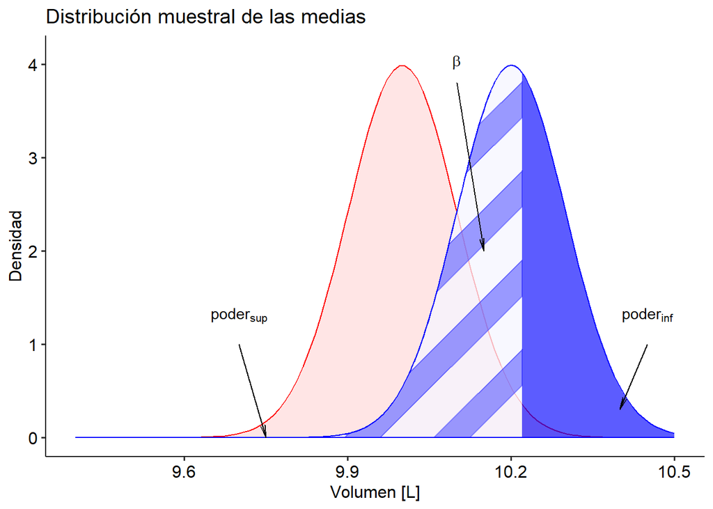

```r
# Traspasar las regiones críticas a la verdadera distribución muestral
# de las medias.
g4 <- g + dist_0 + dist_v
g4 <- g4 + stat_function(fun = dnorm,
                         args = list(mean = media_verdadera, sd = SE),
                         geom = "area",
                         xlim = c(g_x_limites[1], x1),
                         fill = "blue", alpha = 0.6)
g4 <- g4 + stat_function(fun = dnorm,
                         args = list(mean = media_verdadera, sd = SE),
                         geom = "area",
                         xlim = c(x2, g_x_limites[2]),
                         fill = "blue", alpha = 0.6)
g4 <- g4 + stat_function(fun = dnorm,
                         args = list(mean = media_verdadera, sd = SE),
                         geom = "area_pattern",
                         xlim = c(x1, x2),
                         fill = "white", colour = "blue", alpha = 0.3,
                         pattern_spacing = 0.15, pattern_density = 0.4,
                         pattern_fill = "blue", pattern_colour = "blue",
                         pattern_angle = 45, pattern_alpha = 0.3)
g4 <- g4 + stat_function(fun = dnorm,
                         args = list(mean = media_verdadera, sd = SE),
                         geom = "area_pattern",
                         xlim = c(x1, x2),
                         fill = "white", colour = "blue", alpha = 0.6,
                         pattern_spacing = 0.15, pattern_density = 0.4,
                         pattern_fill = "blue", pattern_colour = "blue",
                         pattern_angle = 45, pattern_alpha = 0.3)
# Agrega anotación del poder
g4 <- g4 + annotate("text", x = 10.45, y = 1.4, label = "poder[inf]",
                    vjust = "top", parse = TRUE)
g4 <- g4 + annotate("text", x = 9.7, y = 1.4, label = "poder[sup]",
                    vjust = "top", parse = TRUE)
g4 <- g4 + annotate("text", x = sum(x_ann) / 2, y = y_ann[1] + 0.1,
                    label = "beta", vjust = "top", parse = TRUE)
g4 <- g4 + annotate("segment", x = 10.45, y = 1, xend = 10.4, yend = 0.3,
                    arrow = arrow(angle = 10, length = unit(0.03, "npc"),
                                  ends = "last", type = "open"))
g4 <- g4 + annotate("segment", x = 9.7, y = 1, xend = 9.75, yend = 0,
                    arrow = arrow(angle = 10, length = unit(0.03, "npc"),
                                  ends = "last", type = "open"))
g4 <- g4 + annotate("segment", x = sum(x_ann) / 2, y = y_ann[1] - 0.2,
                    xend = 10.15, yend = 2,
                    arrow = arrow(angle = 10, length = unit(0.03, "npc"),
                                  ends = "last", type = "open"))
print(g4)
```

Finalmente calculamos la probabilidad de cometer error de tipo II

```r
# Límites para rechazar H0
lim_inferior <- 9.78
lim_superior <- 10.22

# Nueva media poblacional verdadera
media_verdadera <- 10.2

# Calcular la probabilidad de cometer un error Tipo II (β)
poder_inf <- pnorm(lim_inferior, mean = media_verdadera, sd = SE, lower.tail = TRUE)
poder_sup <- pnorm(lim_superior, mean = media_verdadera, sd = SE, lower.tail = FALSE)

poder <- poder_inf + poder_sup
beta <- 1 - poder

# Imprimir la probabilidad de cometer un error Tipo II
print(paste("Probabilidad de cometer error de Tipo II =", beta))
```

```
## [1] "Probabilidad de cometer error de Tipo II = 0.579246363690092"
```

Si tuvieramos como verdadera media 10,2[L] con los limites establecidos previamente para rechazar la hipotesis nula, la probabilidad de que cometa un error de tipo II sería β: 0.58

# Problema 3: Como no se conoce el verdadero volumen medio, genere un gráfico del poder estadístico con las condiciones anteriores, pero suponiendo que el verdadero volumen medio podría variar de 9,5 a 10,5 litros. Hay un ejemplo de este tipo de gráfico en la lectura sobre poder estadístico.

```r
# Inicializar poder
poder_inf <- 0
poder_sup <- 1

# Calcular poder_inf si umbral_inf no es nulo
if(!is.null(x1)) {
  poder_inf <- pnorm(x1, mean = media_poblacional, sd = SE, lower.tail = TRUE)
}

# Calcular poder_sup si umbral_sup no es nulo
if(!is.null(x2)) {
  poder_sup <- pnorm(x2, mean = media_poblacional, sd = SE, lower.tail = FALSE)
}

# Calcular poder total
poder <- poder_inf + poder_sup

# Mostrar el poder calculado
print(poder)
```

```
## [1] 0.0278069
```

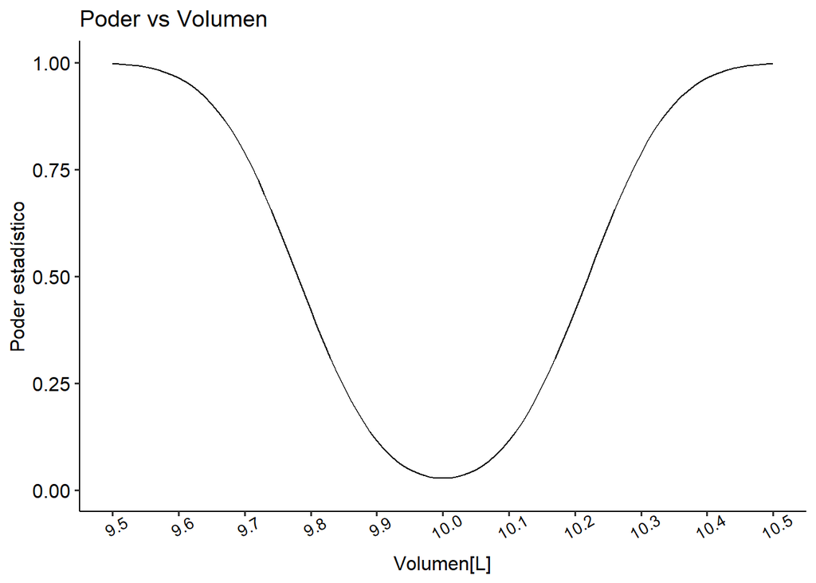

```r
# Crear secuencia de valores para x3
x3 <- seq(9.5, 10.5, 0.01)

# Calcular y3 directamente
y3 <- sapply(x3, function(media_poblacional) {
  poder_inf <- 0
  poder_sup <- 1

  if(!is.null(x1)) {
    poder_inf <- pnorm(x1, mean = media_poblacional, sd = SE, lower.tail = TRUE)
  }
  if(!is.null(x2)) {
    poder_sup <- pnorm(x2, mean = media_poblacional, sd = SE, lower.tail = FALSE)
  }

  return(poder_inf + poder_sup)
})

# Crear el data frame para ggplot
distr3 <- data.frame(x = x3, y = y3)

# Crear el gráfico
g.3.bilateral <- ggplot(distr3, aes(x, y)) + ylim(c(0, 1))
g.3.bilateral <- g.3.bilateral +
 scale_x_continuous(name = "Volumen[L]",
 breaks = seq(round(min(x3), 1), round(max(x3), 1), 0.1))
g.3.bilateral <- g.3.bilateral + geom_line()
g.3.bilateral <- g.3.bilateral + ylab("Poder estadístico")
g.3.bilateral <- g.3.bilateral + theme_pubr()
g.3.bilateral <- g.3.bilateral +
 theme(axis.text.x = element_text(angle = 30, size = 10))
g.3.bilateral <- g.3.bilateral + ggtitle("Poder vs Volumen")

# Mostrar el gráfico
print(g.3.bilateral)
```

Podemos apreciar de la gráfica que el poder se acerca a 1 cuando los litros son distintos a la hipótesis nula que corresponden a 10 Litros.

# Problema 4: Considerando un volumen medio de 10 litros, ¿cuántos bidones deberían revisarse para conseguir un poder estadístico de 0,75 y un nivel de significación de 0,05?

Considerando que nos preguntan sobre la cantidad de bidones y que además nos entregan el poder estadístico y el nivel de significación α podemos utilizar la función pwr.norm.test() otorgándole valor NULL al tamaño de la muestra para que nos lo retorne y sepamos la cantidad de bidones.

```r
#Se definen el nivel de significancia y poder dados en el enunciado
alpha = 0.05
poder = 0.75

#Tamaño del efecto d de Cohen (divide por 1, porque desviación estándar = 1) en donde restamos la media verdadera de la pregunta 2 con la media de nuestra hipotesis nula para luego dividirlo por la desviacion estándar
d = (media_verdadera - media_poblacional)/desviacion_estandar

# Se usa pwr.norm.test para una prueba bilateral dandole vaor NULL a n que corresponde al tamaño de la muestra.
resultado = pwr.norm.test(d = d, n = NULL, sig.level = alpha, power = poder, alternative = "two.sided")
print(resultado)
```

```
##
##      Mean power calculation for normal distribution with known variance
##
##               d = 0.2
##               n = 173.5078
##       sig.level = 0.05
##           power = 0.75
##     alternative = two.sided
```

```r
#Se extrae el dato del tamaño de la muestra del calculo anterior
n = resultado$n
n = ceiling(n)

cat("La cantidad de bidones a revisar para conseguir un poder de 0.75 mediante un nivel de significancia del 5% son:", n)
```

```
## La cantidad de bidones a revisar para conseguir un poder de 0.75 mediante un nivel de significancia del 5% son: 174
```

# Problema 5: ¿Alcanzaría esta muestra para detectar la diferencia que la ingeniera sospecha que existe entre las dos máquinas de la planta con las mismas probabilidades de cometer errores?

Primero se definen las hipótesis nula y alternativa:

H0 = $n_{1} = n_{2};$ $n_{1}:$ 100 , $n_{2}:$ n esperados para la muestra - (No se puede determinar una diferencia entre las probabilidades de cometer un error entre las dos máquinas)

HA = $\mu{1} \neq \mu{2}$ - (Si se puede determinar una diferencia entre las probabilidades de cometer un error entre las dos máquinas)

Luego, utilizando los elementos ya definidos en el problema anterior tenemos:

```r
#Se define el tamaño muestral dado por el enunciado
n_inic = 100

#Calculando proporciones para máquina 1(antigua) y 2(nueva)
p1 = 90/100
p2 = 96/100

#Ahora se calcula el tamaño del efecto (H de Cohen)
tam_efecto = 2*asin(sqrt(p1)) - 2*asin(sqrt(p2))

#Recordando que se usan 2 máquinas, una la cual produce un 90% de sus envases con el volumen adecuado (10 litros) y otra al 96%, se utiliza la función de cálculo de potencia para 2 proporciones de igual tamaño muestral para calcular el número de envases necesarios para cubrir la potencia y alpha dado (calculando como n = NULL)
cantidad = pwr.2p.test(h = tam_efecto, n = NULL, power = poder, sig.level = alpha, alternative = "two.sided")
print(cantidad)
```

```
##
##      Difference of proportion power calculation for binomial distribution (arcsine transformation)
##
##               h = 0.2407853
##               n = 239.4137
##       sig.level = 0.05
##           power = 0.75
##     alternative = two.sided
##
## NOTE: same sample sizes
```

```r
#Se extrae el componente "n" (tamaño de la muestra) obtenido en la función
n = ceiling(cantidad$n)

if(n_inic > n){
  cat("La muestra dada por el enunciado es suficiente para poder encontrar una diferencia entre las dos máquinas y sus resultados")
} else{
  cat("La muestra dada por el enunciado NO es suficiente para poder encontrar una diferencia entre las dos máquinas y sus resultados")
}
```

```
## La muestra dada por el enunciado NO es suficiente para poder encontrar una diferencia entre las dos máquinas y sus resultados
```